# Material complementario · Taller 6

- Mostrar todo el código
- Ocultar todo el código
- Ver el código fuente

Complementos de exploración gráfica · Semana 3

Autor/a

Javier Rodríguez-Barrios

Fecha de publicación

20 de octubre de 2026

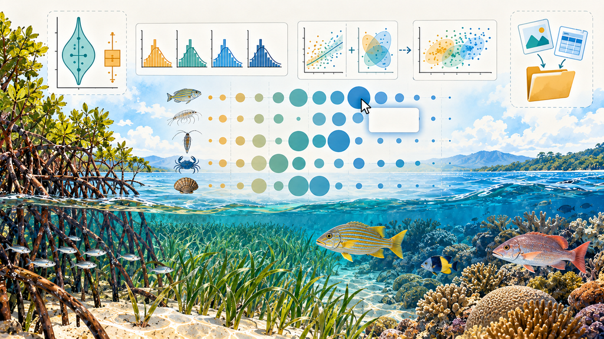

## Cómo usar este material

Este documento amplía el [Taller 6 · Exploración gráfica multivariada](https://javier-2712.github.io/Manuales/8.Manual_diseno_msc/html/Taller6_Exploracion.html). No es necesario recorrerlo completo: cada sección es independiente y responde a una situación que puede aparecer al preparar las figuras del CQ2, del estudio de caso o del propio proyecto de grado.

| Situación | Sección |
| --- | --- |
| Se quiere construir una figura de burbujas paso a paso y controlar escalas, orden y leyendas | 1. Burbujas paso a paso |
| Se prefiere la sintaxis de fórmulas (`~ x \| grupo`) o se quiere ver la forma de una distribución con un violín | 2. Distribuciones con lattice y violines |
| Se quieren comparar grupos definidos por tres factores a la vez | 3. Cajas con tres factores |
| Se quiere explorar una figura pasando el cursor sobre los puntos | 4. Burbujas interactivas con plotly |
| Se necesitan dos o más figuras en un mismo panel | 5. Paneles de figuras |
| Se quiere que las figuras y tablas queden guardadas en archivos al renderizar | 6. Guardado automático |
| Se quiere practicar sin nota antes del CQ2 | 7. Ejercicios de práctica |

**Código**

```r
# Librerías requeridas
library(tidyverse)
library(readxl)
library(kableExtra)
library(lattice)     # Figuras con fórmulas (sección 2)
library(gridExtra)   # Paneles de figuras (sección 5)
library(plotly)      # Figuras interactivas (sección 4)
library(writexl)     # Guardar tablas en Excel (sección 6)

# Paletas del Taller 6
col_cuenca <- c(cuen1 = "#fc8d59", cuen2 = "#fee08b",
                cuen3 = "#99d594", cuen4 = "#377eb8")
col_capa   <- c(Profunda = "#2C6FB7", Superficial = "#E3A33B")

# Leyenda dentro del panel: la sintaxis cambió en ggplot2 3.5.0
leyenda_dentro <- function(x, y) {
  if (packageVersion("ggplot2") >= "3.5.0") {
    theme(legend.position = "inside",
          legend.position.inside = c(x, y),
          legend.justification = c(x, y))
  } else {
    theme(legend.position = c(x, y),
          legend.justification = c(x, y))
  }
}
```

**Código**

```r
# Bases del Taller 6
# Insectos: base hipotética de 4 cuencas × 5 quebradas
ins <- read_excel("Insectos.xlsx", sheet = "Insectos") %>%
  mutate(cuenca = factor(cuenca))

# Plancton: hoja «Riqueza» depurada (formato largo)
biol <- read_xlsx("plancton.xlsx", sheet = "Riqueza") %>%
  mutate(Groups  = str_trim(Groups),
         Station = factor(Station),
         Size    = factor(Size),
         Layers  = recode_factor(Layers, Depth = "Profunda",
                                 Surface = "Superficial"))
taxones <- unique(biol$Groups)

# Plancton: base ancha (una fila por estación × malla × capa), como en el Taller 6
pl_ancho <- biol %>%
  group_by(Station, Size, Layers) %>%
  summarise(across(c(Temperature, Salinity, Density), mean),
            .groups = "drop") %>%
  left_join(biol %>%
              group_by(Station, Size, Layers, Groups) %>%
              summarise(Abundance = sum(Abundance),
                        .groups = "drop") %>%
              pivot_wider(names_from = Groups,
                          values_from = Abundance,
                          values_fill = 0),
            by = c("Station", "Size", "Layers")) %>%
  mutate(Ab = rowSums(across(all_of(taxones))))
```

## 1. Burbujas paso a paso: datos hipotéticos

**Pregunta:** ¿Qué decisiones de diseño hacen que una figura de burbujas se lea bien?

En el Taller 6 la figura de burbujas se construye directamente con los datos del plancton. Con una base pequeña e inventada es más fácil ver qué cambia con cada ajuste. Los datos son **hipotéticos**: abundancia de cinco especies de peces en censos visuales a distintas profundidades, en tres hábitats.

**Código**

```r
# Datos hipotéticos: especie, profundidad (m), hábitat y abundancia
peces <- tribble(
  ~especie,                  ~prof, ~habitat,       ~abund,
  "Haemulon flavolineatum",      3, "Arrecife",         85,
  "Haemulon flavolineatum",      8, "Arrecife",        120,
  "Haemulon flavolineatum",     15, "Arrecife",         40,
  "Stegastes partitus",          8, "Arrecife",         60,
  "Stegastes partitus",         15, "Arrecife",         95,
  "Stegastes partitus",         20, "Arrecife",         30,
  "Lutjanus apodus",             2, "Manglar",          35,
  "Lutjanus apodus",             8, "Arrecife",         15,
  "Sparisoma radians",           2, "Pastos marinos",   70,
  "Sparisoma radians",           4, "Pastos marinos",   55,
  "Sparisoma radians",           8, "Arrecife",         10,
  "Gerres cinereus",             1, "Manglar",          50,
  "Gerres cinereus",             3, "Pastos marinos",   25
)

# Tabla con los datos
peces %>%
  kbl(booktabs = TRUE) %>%
  kable_classic(full_width = F) %>%
  row_spec(0, bold = TRUE)
```

| especie | prof | habitat | abund |
| --- | --- | --- | --- |
| Haemulon flavolineatum | 3 | Arrecife | 85 |
| Haemulon flavolineatum | 8 | Arrecife | 120 |
| Haemulon flavolineatum | 15 | Arrecife | 40 |
| Stegastes partitus | 8 | Arrecife | 60 |
| Stegastes partitus | 15 | Arrecife | 95 |
| Stegastes partitus | 20 | Arrecife | 30 |
| Lutjanus apodus | 2 | Manglar | 35 |
| Lutjanus apodus | 8 | Arrecife | 15 |
| Sparisoma radians | 2 | Pastos marinos | 70 |
| Sparisoma radians | 4 | Pastos marinos | 55 |
| Sparisoma radians | 8 | Arrecife | 10 |
| Gerres cinereus | 1 | Manglar | 50 |
| Gerres cinereus | 3 | Pastos marinos | 25 |

### 1.1 Figura base

**Código**

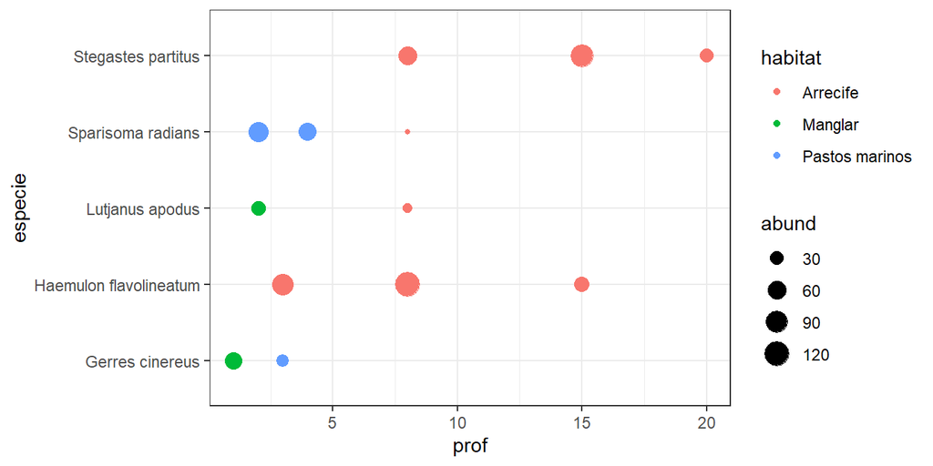

Figura 1: Figura de burbujas básica con los valores por defecto de ggplot2.

```r
# Tamaño = abundancia; color = hábitat
ggplot(peces, aes(x = prof,
                  y = especie,
                  size = abund,
                  color = habitat)) +
  geom_point() +
  theme_bw()
```

Con los valores por defecto, las especies aparecen en orden alfabético, las burbujas pequeñas casi no se ven y la cuadrícula compite con los datos.

### 1.2 Orden, escalas y líneas de referencia

**Código**

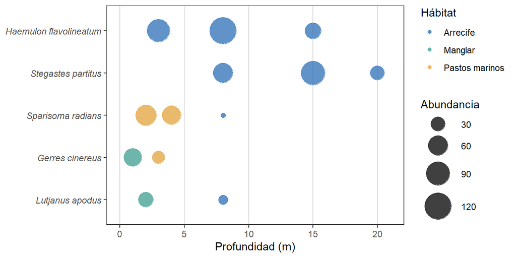

Figura 2: Burbujas con las especies ordenadas por abundancia total, rango de tamaños ajustado y líneas verticales de referencia.

```r
# Ordenar las especies por abundancia total (la más abundante arriba)
peces <- peces %>%
  mutate(especie = fct_reorder(especie, abund, .fun = sum))

# Figura con escalas y guías
p_burb <- ggplot(peces, aes(x = prof,
                            y = especie,
                            size = abund,
                            color = habitat)) +
  geom_vline(xintercept = seq(0, 20, by = 5), color = "grey85") +   # Guías
  geom_point(alpha = 0.75) +
  scale_size(range = c(2, 12), name = "Abundancia") +               # Rango de tamaños
  scale_color_manual(values = c(Arrecife = "#2C6FB7",
                                Manglar = "#3E9C8F",
                                `Pastos marinos` = "#E3A33B"),
                     name = "Hábitat") +
  scale_x_continuous(limits = c(0, 21),
                     breaks = seq(0, 20, by = 5)) +
  labs(x = "Profundidad (m)", y = NULL) +
  theme_bw() +
  theme(panel.grid = element_blank(),
        axis.text.y = element_text(face = "italic"))
p_burb
```

Tres decisiones cambian la lectura: el **orden** de las especies (por abundancia total, con `fct_reorder()`), el **rango de tamaños** (`scale_size(range = ...)`, para que las burbujas pequeñas se vean y las grandes no se tapen) y las **líneas verticales** (`geom_vline()`), que reemplazan la cuadrícula completa. Los nombres científicos van en cursiva.

**NotaEl tamaño se escala por área**

`scale_size()` hace que el **área** de la burbuja sea proporcional al valor, que es como el ojo compara círculos. Si el tamaño se escalara por el radio, una burbuja del doble de abundancia se vería cuatro veces más grande.

### 1.3 Leyendas: afuera, con círculos vacíos

**Código**

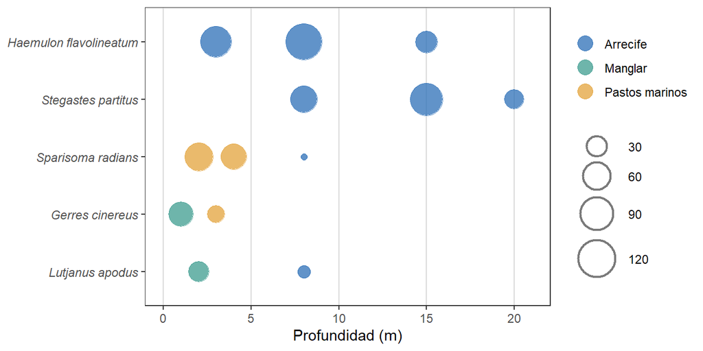

Figura 3: Leyenda afuera del panel, sin títulos, con círculos vacíos en la leyenda de tamaño.

```r
# Círculos vacíos para el tamaño y puntos grandes para el color
p_burb +
  guides(size  = guide_legend(title = NULL,
                              override.aes = list(shape = 1,
                                                  color = "grey30",
                                                  stroke = 1.1)),
         color = guide_legend(title = NULL,
                              override.aes = list(size = 5)))
```

Los círculos vacíos muestran el tamaño sin sugerir un hábitat, y los puntos grandes en la leyenda de color hacen que los colores se distingan.

### 1.4 Leyenda dentro del panel

Cuando hay una zona del panel sin datos, la leyenda puede ir allí y la figura gana ancho. La función `leyenda_dentro()`, definida al inicio, usa la sintaxis que corresponde a la versión de `ggplot2` instalada.

**Código**

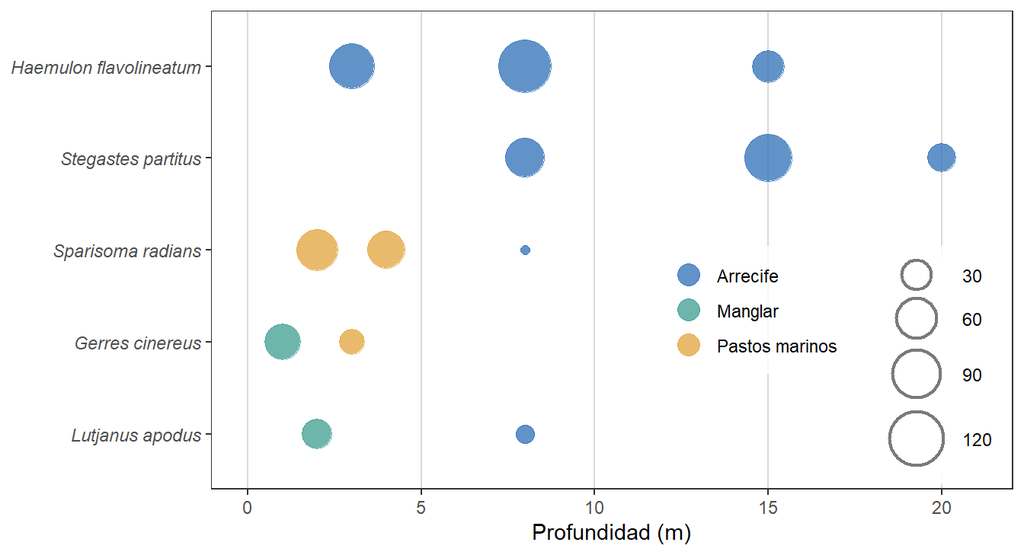

Figura 4: Leyenda dentro del panel, en la zona de mayor profundidad, donde no hay burbujas de las especies inferiores.

```r
# Leyenda en la esquina inferior derecha
p_burb +
  guides(size  = guide_legend(title = NULL,
                              override.aes = list(shape = 1,
                                                  color = "grey30",
                                                  stroke = 1.1)),
         color = guide_legend(title = NULL,
                              override.aes = list(size = 5))) +
  leyenda_dentro(0.98, 0.02) +
  theme(legend.box = "horizontal",
        legend.background = element_rect(fill = alpha("white", 0.85), color = NA))
```

**Para discutir:** en esta figura cada burbuja es un censo. Si en una profundidad se hubieran hecho tres censos, ¿se dibujarían tres burbujas superpuestas o una con la abundancia media? ¿Qué pregunta responde cada opción?

## 2. Distribuciones con lattice y violines

**Pregunta:** ¿Cómo se ve la distribución de la abundancia de insectos en cada cuenca con otra sintaxis gráfica?

El paquete `lattice` (incluido en R) construye figuras por paneles con una **fórmula**: `~ x | grupo` se lee «x, un panel por grupo». Es la misma idea de `facet_wrap()`, con otra sintaxis.

| Figura | `lattice` | `ggplot2` |
| --- | --- | --- |
| Histograma por grupo | `histogram(~ Ab \| cuenca)` | `geom_histogram() + facet_wrap(~ cuenca)` |
| Densidades superpuestas | `densityplot(~ Ab, groups = cuenca)` | `geom_density(aes(fill = cuenca))` |
| Cajas por grupo | `bwplot(Ab ~ cuenca)` | `geom_boxplot()` |

**Código**

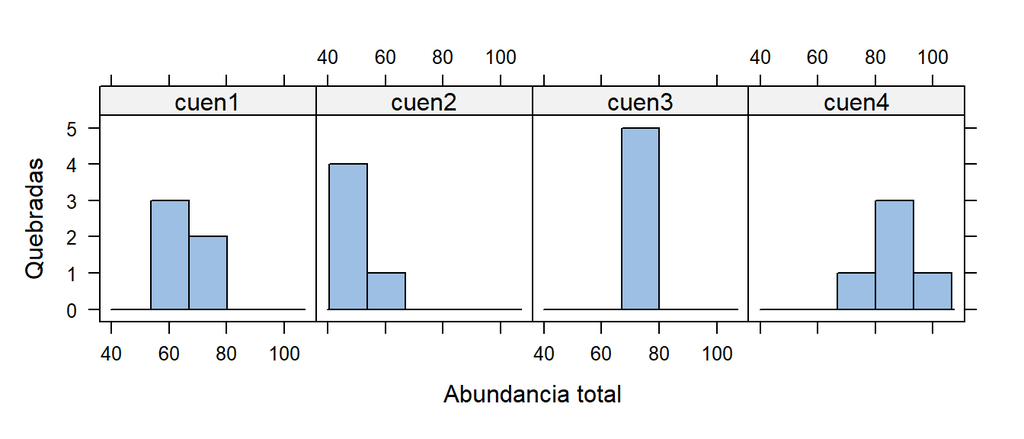

Figura 5: Histogramas de la abundancia total de insectos, un panel por cuenca (lattice).

```r
# Histograma con un panel por cuenca, en una fila
histogram(~ Ab | cuenca, data = ins, layout = c(4, 1),
          type = "count", col = "#9DBFE3",
          xlab = "Abundancia total", ylab = "Quebradas")
```

**Código**

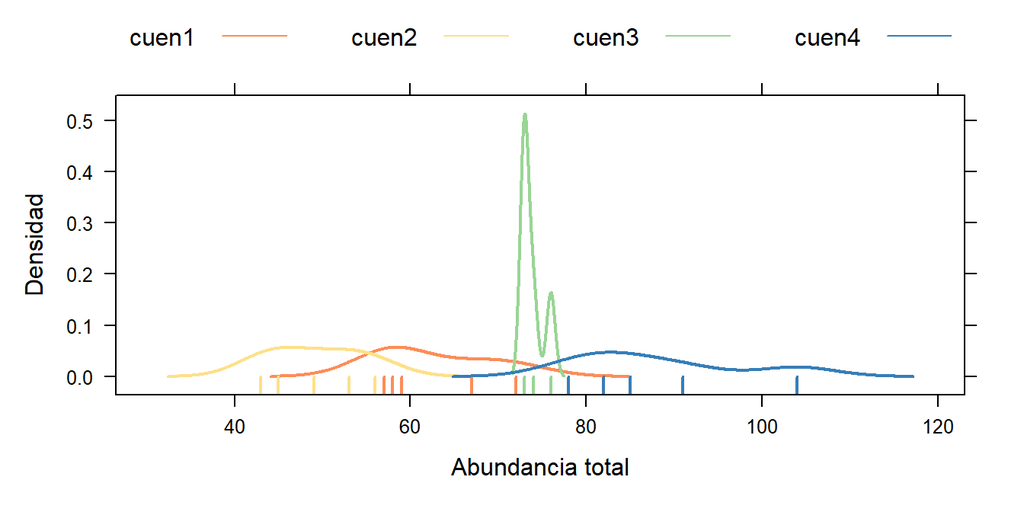

Figura 6: Densidades de la abundancia total de insectos por cuenca, con las quebradas como marcas en la base (lattice).

```r
# Densidades superpuestas, con leyenda automática
densityplot(~ Ab, groups = cuenca, data = ins,
            plot.points = "rug", lwd = 2,
            par.settings = list(superpose.line = list(col = col_cuenca)),
            auto.key = list(columns = 4, lines = TRUE, points = FALSE),
            xlab = "Abundancia total", ylab = "Densidad")
```

**Código**

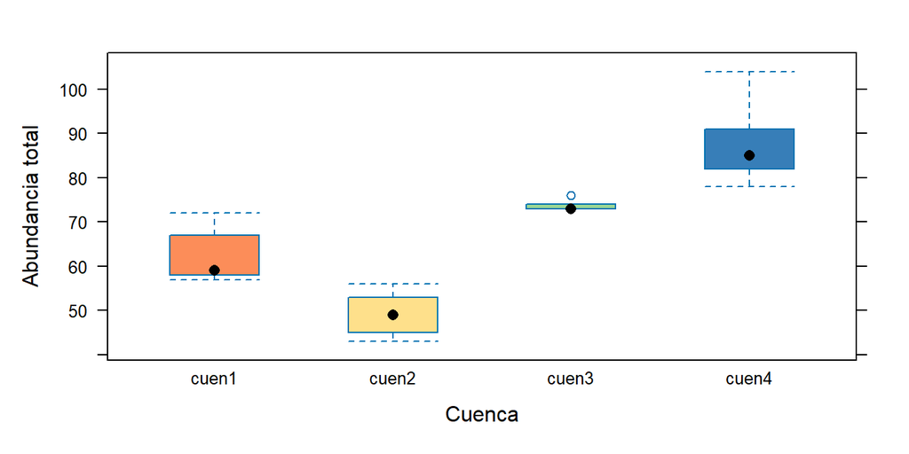

Figura 7: Cajas de la abundancia total de insectos por cuenca (lattice).

```r
# Cajas por cuenca
bwplot(Ab ~ cuenca, data = ins, fill = col_cuenca,
       xlab = "Cuenca", ylab = "Abundancia total")
```

### Violines: cuándo sí y cuándo no

Un violín es una curva de densidad dibujada a los dos lados de un eje. Muestra la **forma** de la distribución (asimetría, dos picos) que una caja oculta, pero necesita datos suficientes. Se comparan los lirios del Taller 5 (50 flores por especie) con los insectos (5 quebradas por cuenca):

**Código**

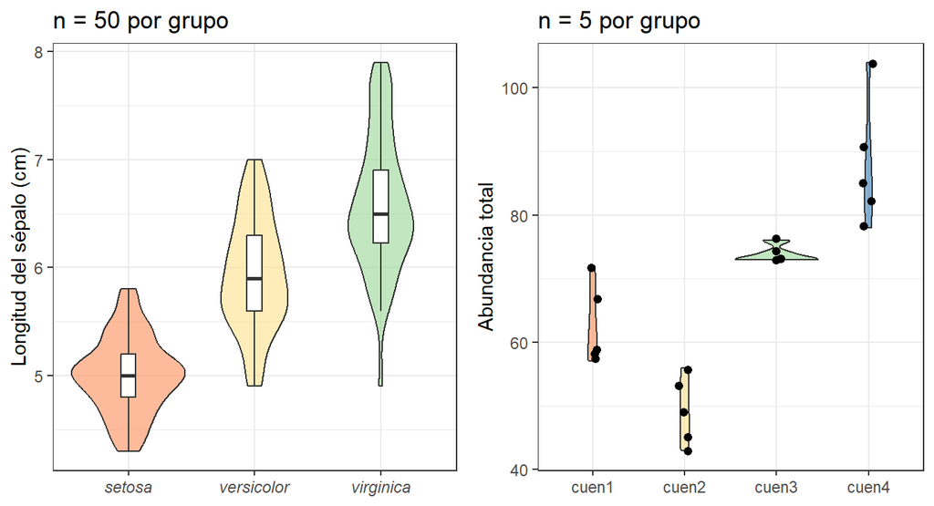

Figura 8: Violines con una caja estrecha en el centro. Izquierda: longitud del sépalo de tres especies de Iris (n = 50 por especie). Derecha: abundancia total de insectos por cuenca (n = 5 por cuenca), con los datos encima.

```r
# Violín con muchos datos por grupo (lirios)
v1 <- ggplot(iris, aes(x = Species, y = Sepal.Length, fill = Species)) +
  geom_violin(alpha = 0.6) +
  geom_boxplot(width = 0.12,
               fill = "white",
               outlier.shape = NA) +
  scale_fill_manual(values = c("#fc8d59", "#fee08b", "#99d594"), guide = "none") +
  labs(x = NULL, y = "Longitud del sépalo (cm)", title = "n = 50 por grupo") +
  theme_bw() +
  theme(axis.text.x = element_text(face = "italic"))

# Violín con pocos datos por grupo (insectos)
v2 <- ggplot(ins, aes(x = cuenca,
                      y = Ab,
                      fill = cuenca)) +
  geom_violin(alpha = 0.6) +
  geom_jitter(width = 0.06, size = 1.8) +
  scale_fill_manual(values = col_cuenca,
                    guide = "none") +
  labs(x = NULL,
       y = "Abundancia total",
       title = "n = 5 por grupo") +
  theme_bw()

# Las dos figuras lado a lado (ver sección 5)
grid.arrange(v1, v2, ncol = 2)
```

Con 50 flores por especie, el violín describe bien la forma de cada distribución. Con 5 quebradas, la curva es una suavización de cinco puntos: su forma depende más del ancho de banda que de los datos. Para grupos pequeños, la figura del Taller 6 (cajas con los puntos encima) es más honesta.

**AdvertenciaDiseño (RA1)**

Ninguna figura agrega información que el muestreo no tenga. Con pocas réplicas por grupo, conviene mostrar los datos individuales y dejar las figuras de densidad (violines, densidades) para grupos con suficientes observaciones.

## 3. Cajas con tres factores

**Pregunta:** ¿Cambia la abundancia total del mesozooplancton con la salinidad y la temperatura, en cada capa?

Las dos variables ambientales se categorizan en terciles **a nivel de muestra** (base ancha), como en el Taller 6.

**Código**

```r
# Terciles de salinidad y de temperatura en la base ancha
pl_ancho <- pl_ancho %>%
  mutate(Sal_niv  = cut(Salinity, quantile(Salinity, c(0, 1/3, 2/3, 1)),
                        labels = c("S. baja", "S. media", "S. alta"),
                        include.lowest = TRUE),
         Temp_niv = cut(Temperature, quantile(Temperature, c(0, 1/3, 2/3, 1)),
                        labels = c("T. baja", "T. media", "T. alta"),
                        include.lowest = TRUE))

# Muestras en cada combinación de salinidad, temperatura y capa
n_celdas <- pl_ancho %>% count(Layers, Sal_niv, Temp_niv, .drop = FALSE)

n_celdas %>%
  pivot_wider(names_from = Temp_niv, values_from = n) %>%
  kbl(booktabs = TRUE, col.names = c("Capa", "Salinidad",
                                     "T. baja",
                                     "T. media",
                                     "T. alta")) %>%
  kable_classic(full_width = F) %>%
  row_spec(0, bold = TRUE)
```

| Capa | Salinidad | T. baja | T. media | T. alta |
| --- | --- | --- | --- | --- |
| Profunda | S. baja | 2 | 0 | 3 |
| Profunda | S. media | 1 | 2 | 0 |
| Profunda | S. alta | 1 | 3 | 0 |
| Superficial | S. baja | 1 | 1 | 1 |
| Superficial | S. media | 1 | 2 | 2 |
| Superficial | S. alta | 2 | 0 | 2 |

Antes de graficar, la tabla muestra el problema: de las 18 combinaciones de capa, salinidad y temperatura, 4 están vacías y 6 tienen una sola muestra. Con 24 muestras, tres factores dejan muy pocos datos por celda.

**Código**

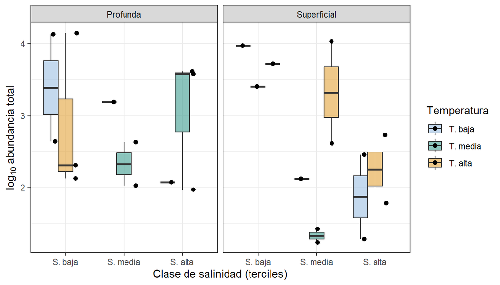

Figura 9: Abundancia total del mesozooplancton (log10) según la clase de salinidad (eje X), la clase de temperatura (color) y la capa (paneles). Cada punto es una muestra.

```r
# Cajas con los puntos encima, un panel por capa
ggplot(pl_ancho, aes(x = Sal_niv,
                     y = log10(Ab), fill = Temp_niv)) +
  geom_boxplot(alpha = 0.6, outlier.shape = NA,
               position = position_dodge(preserve = "single")) +
  geom_point(position = position_jitterdodge(jitter.width = 0.1, dodge.width = 0.75),
             size = 1.8) +
  scale_fill_manual(values = c("#9DBFE3", "#3E9C8F", "#E3A33B"),
                    name = "Temperatura") +
  facet_wrap(~ Layers) +
  labs(x = "Clase de salinidad (terciles)",
       y = expression(log[10]~"abundancia total")) +
  theme_bw()
```

**Código**

```r
# Correlación entre las dos variables que se categorizaron
r_ts <- cor(pl_ancho$Salinity, pl_ancho$Temperature)
round(r_ts, 2)
```

```
[1] 0.09
```

**AdvertenciaDiseño (RA1): factores derivados de variables medidas**

La temperatura y la salinidad no se asignaron como tratamientos: se midieron. En estas muestras casi no están correlacionadas (r = 0.09), pero al cortarlas en terciles y cruzarlas con la capa, las 24 muestras se reparten en 18 celdas: unas quedan vacías y otras con una sola muestra, sin réplicas para estimar la variación dentro de la celda. La figura describe dónde caen las muestras, pero no permite comparar celdas ni probar interacciones. Para eso, las dos variables se usan como continuas en un modelo (Taller 3) o en una ordenación restringida (Taller 9).

**Para discutir:** en un proyecto propio con un diseño factorial real (tratamientos asignados), ¿por qué la tabla de n por celda sería distinta de esta?

## 4. Burbujas interactivas con plotly

**Pregunta:** ¿Qué muestra cada burbuja de la figura del plancton?

`plotly::ggplotly()` convierte una figura de `ggplot2` en una figura interactiva: al pasar el cursor sobre una burbuja aparece su información, y se puede acercar y alejar. Se usa la base ancha, de modo que cada burbuja sea **una muestra** (ver la Pregunta 5 del CQ2).

**Código**

```r
# Ocho taxones más abundantes
top8 <- biol %>%
  group_by(Groups) %>%
  summarise(Total = sum(Abundance)) %>%
  slice_max(Total, n = 8) %>%
  pull(Groups)

# Base ancha en formato largo: una fila por muestra y taxón presente
burb_m <- pl_ancho %>%
  select(Station, Size, Layers, Salinity, all_of(top8)) %>%
  pivot_longer(all_of(top8), names_to = "Grupo", values_to = "Abundancia") %>%
  filter(Abundancia > 0) %>%
  mutate(Grupo = factor(Grupo, levels = rev(top8)),
         info  = paste0("Estación ", Station, " · ", Size, " · ", Layers,
                        "<br>Salinidad: ", round(Salinity, 1),
                        "<br>Abundancia: ", Abundancia))

# Figura estática con el texto de ayuda en la estética «text»
p_int <- ggplot(burb_m, aes(x = Salinity, y = Grupo, size = Abundancia,
                            color = Station, text = info)) +
  geom_point(alpha = 0.6) +
  scale_size(range = c(1, 10)) +
  scale_color_viridis_d(end = 0.9, name = "Estación") +
  labs(x = "Salinidad media de la muestra", y = NULL) +
  theme_bw()

# Versión interactiva: solo se muestra el texto definido en «info»
ggplotly(p_int, tooltip = "text")
```

[interactive chart not shown]

Figura 10: Burbujas interactivas de los ocho taxones más abundantes frente a la salinidad media de cada muestra. Pasar el cursor sobre una burbuja muestra la estación, la malla, la capa y la abundancia.

La figura tiene 149 burbujas, una por cada muestra en la que el taxón estuvo presente. La versión interactiva sirve para explorar y para revisar valores atípicos, pero no reemplaza la figura estática en un documento impreso o en un artículo.

**TipEn el render**

`ggplotly()` funciona en el HTML del render; en PDF o Word se pierde la interactividad. Si el documento tiene `embed-resources: true`, la figura queda incluida en el mismo archivo HTML.

## 5. Paneles de figuras

**Pregunta:** ¿Cómo se presentan juntas dos figuras que responden a la misma pregunta?

`gridExtra::grid.arrange()` ubica varias figuras en una cuadrícula. Se comparan, en un solo panel, la posición (cajas) y la forma (densidades) de la abundancia de insectos por cuenca:

**Código**

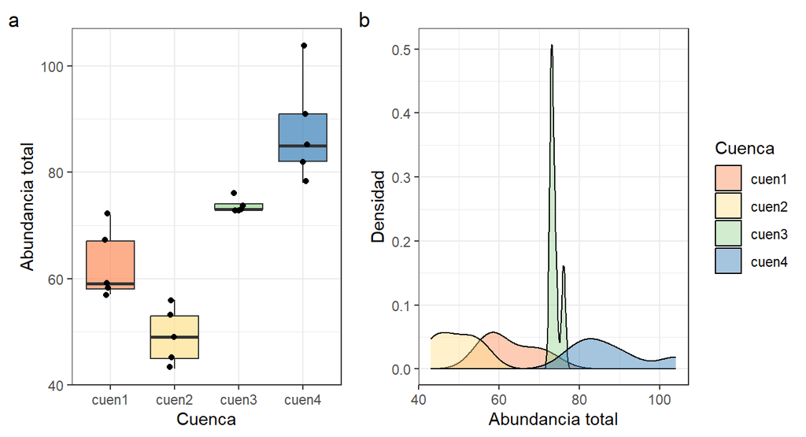

Figura 11: Abundancia total de insectos por cuenca. a) Cajas con las quebradas encima. b) Densidades.

```r
# Figura a: cajas con los datos encima
f_a <- ggplot(ins, aes(x = cuenca, y = Ab, fill = cuenca)) +
  geom_boxplot(alpha = 0.7, outlier.shape = NA) +
  geom_jitter(width = 0.08, size = 1.5) +
  scale_fill_manual(values = col_cuenca, guide = "none") +
  labs(x = "Cuenca", y = "Abundancia total", tag = "a") +
  theme_bw()

# Figura b: densidades superpuestas
f_b <- ggplot(ins, aes(x = Ab, fill = cuenca)) +
  geom_density(alpha = 0.45) +
  scale_fill_manual(values = col_cuenca, name = "Cuenca") +
  labs(x = "Abundancia total", y = "Densidad", tag = "b") +
  theme_bw()

# Dos columnas; con nrow = 2 quedarían una sobre otra
grid.arrange(f_a, f_b, ncol = 2, widths = c(1, 1.3))
```

El argumento `tag` de `labs()` pone la letra de cada panel, que es lo que se cita en el texto («Fig. 1a»). Con `ncol = 2` las figuras quedan lado a lado; con `nrow = 2`, una sobre otra; `widths` reparte el ancho cuando una figura tiene leyenda y la otra no.

**NotaAlternativa: patchwork**

El paquete `patchwork` hace lo mismo con operadores: `f_a + f_b` (lado a lado) o `f_a / f_b` (una sobre otra), y alinea los ejes automáticamente. Requiere instalarlo con `install.packages("patchwork")`.

## 6. Guardado automático de figuras y tablas

**Pregunta:** ¿Cómo se obtienen las figuras y tablas como archivos para la tesis o el artículo, sin copiarlas a mano desde el HTML?

### Todas las figuras del documento

Al inicio del `.qmd`, un bloque oculto le indica a `knitr` dónde y en qué formato guardar **todas** las figuras al renderizar. Se muestra sin ejecutar, para no cambiar las figuras de este documento:

**Código**

```r
# Bloque al inicio del documento (con #| include: false)
dir.create("outputs/fig", recursive = TRUE, showWarnings = FALSE)

knitr::opts_chunk$set(
  dev      = "png",           # Formato de las figuras
  dpi      = 300,             # Resolución para publicación
  fig.path = "outputs/fig/"   # Carpeta (cada figura toma el nombre de su label)
)
```

Cada figura queda con el nombre de su etiqueta (`#| label: fig-...`), así que conviene ponerle a cada bloque una etiqueta descriptiva.

### Una figura en particular

**Código**

```r
# Carpeta de figuras
dir.create("outputs/fig", recursive = TRUE, showWarnings = FALSE)

# Guardar la figura de burbujas de la sección 1 (tamaño en cm, 300 dpi)
ggsave("outputs/fig/burbujas_hipoteticas.png", plot = p_burb,
       width = 18, height = 9, units = "cm", dpi = 300)
```

### Tablas

**Código**

```r
# Carpeta de tablas
dir.create("outputs/tab", recursive = TRUE, showWarnings = FALSE)

# Función para guardar una tabla en Excel (el nombre va sin extensión)
guardar_tabla <- function(tabla, nombre) {
  write_xlsx(tabla, path = file.path("outputs/tab", paste0(nombre, ".xlsx")))
}

# Resumen por cuenca y n por celda de la sección 3
res_cuenca <- ins %>%
  group_by(cuenca) %>%
  summarise(n = n(), media = mean(Ab), de = sd(Ab), ee = sd(Ab) / sqrt(n()))

guardar_tabla(res_cuenca, "resumen_cuencas")
guardar_tabla(n_celdas, "n_celdas_tres_factores")

# Archivos generados
list.files("outputs", recursive = TRUE)
```

```
[1] "fig/burbujas_hipoteticas.png"    "tab/n_celdas_tres_factores.xlsx"
[3] "tab/resumen_cuencas.xlsx"
```

**ImportanteRutas relativas**

Las rutas (`"outputs/fig/..."`) son relativas a la carpeta del `.qmd`. Así el documento renderiza igual en cualquier computador, que es el primer criterio de la rúbrica R2 (reproducibilidad).

## 7. Ejercicios de práctica (sin nota)

Para practicar antes del CQ2, con las bases del Taller 6:

1. Con los datos hipotéticos de la sección 1, ordene las especies por su **profundidad media** en lugar de su abundancia total. ¿Qué cambia en la lectura de la figura?
2. Construya con `lattice` las cajas de Ephemeroptera por cuenca (`bwplot(Efem ~ cuenca)`) y la misma figura con `ggplot2`. ¿Qué ventajas tiene cada sintaxis?
3. Repita la figura de la sección 3 con la malla (`Size`) en lugar de la capa en los paneles, y revise antes la tabla de n por celda.
4. Haga interactiva la figura de dispersión de la abundancia total frente a la densidad del agua (Taller 6, Parte 3), con la estación y la capa en el texto de ayuda.
5. Arme un panel con la dispersión de Ephemeroptera frente al pH y las cajas de Ephemeroptera por cuenca (Taller 6, Partes 1 y 2), con las letras a y b.
6. Guarde ese panel con `ggsave()` a 300 dpi. Como `grid.arrange()` dibuja el panel, primero se guarda en un objeto con `arrangeGrob()` y luego se pasa a `ggsave()`.

## Referencias

- Auguie, B. (2017). *gridExtra: Miscellaneous Functions for “Grid” Graphics*. https://CRAN.R-project.org/package=gridExtra
- Rodríguez-Barrios, J., Ospina-Tórres, R., & Turizo-Correa, R. (2011). Grupos funcionales alimentarios de macroinvertebrados acuáticos en el río Gaira, Colombia. *Revista de Biología Tropical*, 59(4), 1537–1552. https://doi.org/10.15517/rbt.v59i4.3418
- Sarkar, D. (2008). *Lattice: Multivariate Data Visualization with R*. Springer.
- Sievert, C. (2020). *Interactive Web-Based Data Visualization with R, plotly, and shiny*. Chapman and Hall/CRC. https://plotly-r.com
- Vargas-Ospina, B., Córdoba-Bejarano, J. A., Riquelme-Bugueño, R., Flórez-Leiva, L., & Rodríguez-Barrios, J. (2025). Short-term variations of mesozooplankton in a tropical estuary, Caribbean Colombia. *Wetlands*, 45(6), 83. https://doi.org/10.1007/s13157-025-01951-7 — Base de datos `plancton.xlsx`.
- Wickham, H. (2016). *ggplot2: Elegant Graphics for Data Analysis* (2nd ed.). Springer.

**Nota**

La base `Insectos` y los datos de peces de la sección 1 son hipotéticos, con fines didácticos. Las figuras y el código de este material son de elaboración propia; no reproducen ejercicios ni código de las fuentes citadas.